# Urban data lab - day 2 - explorative analysis - charging stations HH

Sven Lautenbach

10/18/2020

# 1 Preparation

```r
dataFolder <- paste0(ws, "data/")
```

Load data from geopackage

```r
charging_stations <- st_read(dsn= paste0(dataFolder, "HH.gpkg"), layer="chargingStations")
```

# 2 Explorative analysis

## 2.1 Kernel density map

We need to creat/define an empty raster that will store the results of the kernel density estimation

Get bounding box of the data

```r
(bboxHH <- st_bbox(charging_stations))
```

```
##      xmin      ymin      xmax      ymax
##  552777.7 5921782.1  581876.5 5954451.3
```

```r
gridsize=c(500,500)
range_x=list(c(bboxHH[1], bboxHH[3]),c(bboxHH[2], bboxHH[4]))
#552378.61, 5921782.142, 582209.533, 5956674.616
kdeMat <-  bkde2D(st_coordinates(charging_stations), bandwidth=c(500,500), gridsize=gridsize, range.x=range_x)
```

Since *bkde2D* returns a matrix we need to convert it to a raster:

```r
kdeRas <- raster(list(x=kdeMat$x1,y=kdeMat$x2,z=kdeMat$fhat), crs=CRS('+init=EPSG:25832') )
```

Scale the raster so that units are more meaningful and create countour lines that we will use in plotting

```r
kdeRas_scaled <- kdeRas*xres(kdeRas)*yres(kdeRas)* nrow(charging_stations)
cellStats(kdeRas_scaled$layer, stat=sum )
```

```
## [1] 1051.721
```

```r
kdeRas_scaledContour <- rasterToContour(kdeRas_scaled)  %>%   st_as_sf()
```

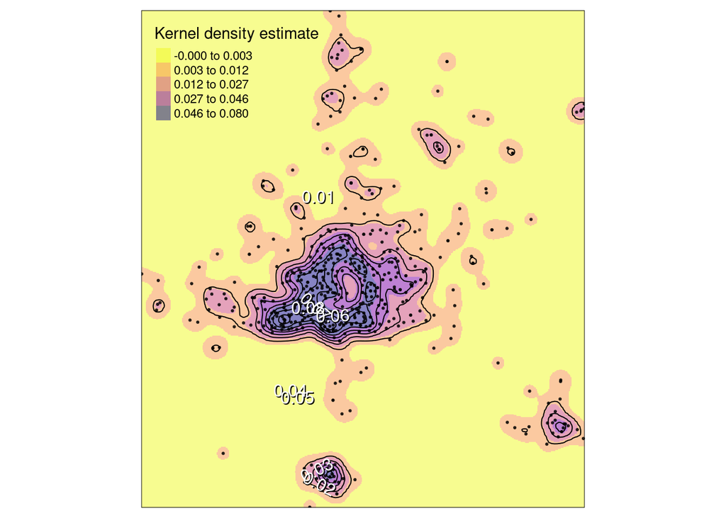

```r
tm_shape(kdeRas_scaled) + tm_raster(col="layer", alpha = .5, palette ="-plasma", title = "Kernel density estimate", style = "kmeans" ) + tm_shape(charging_stations) + tm_dots(alpha=.5) + tm_shape(kdeRas_scaledContour) + tm_lines() + tm_text(text="level", col="white", shadow=TRUE, along.lines=TRUE)
```

## 2.2 How far are the stations away from each other?

We use a for loop to calculate the distance to the clostet charging station in the data set. Therefore, we loop over all points and calculate the distance between the point i and all points including itself. This rather brute force approache returns the whole distance matrix which when can be used to calculate differences.

```r
n <- nrow(charging_stations)
distMat <- matrix(data=0, nrow=n, ncol=n)
for(i in seq_len(n))
{
  allDists <- st_distance(charging_stations, charging_stations[i,])
  distMat[i,] <- allDists

}
```

In many cases several charging stations are at the same point, rendering a distance of zero.

```r
getSecondSmallest <- function(x, pos=2)
{
   sort(x)[pos]
}
dist2Shortest <- apply(distMat, MARGI=1, FUN= getSecondSmallest, pos=2)
summary(dist2Shortest)
```

```
##     Min.  1st Qu.   Median     Mean  3rd Qu.     Max.
##   0.0000   0.0000   0.0000   0.5075   0.0000 328.8055
```

We can force the analysis to deliver us the shortest distance to a neighbor not at the same location. Therefore, we: * sort values * get the indices of all values larger than zero * get the first element of the indices that is larger then zero

```r
getSecondSmallestNotAtSame <- function(x, pos=1)
{
   sortedValues <- sort(x)
   idx <- which(sortedValues > 0)
   return(sortedValues[idx][pos])
}
dist2ShortestNotAtSame <- apply(distMat, MARGI=1, FUN= getSecondSmallestNotAtSame)
summary(dist2ShortestNotAtSame)
```

```
##    Min. 1st Qu.  Median    Mean 3rd Qu.    Max.
##   19.93  201.27  287.89  407.80  456.17 5425.73
```

Or we could get the average distance to the closest ten charging stations

```r
getMeanDistToClostest <- function(x, n=10)
{
   sortedValues <- sort(x)
   return(mean(sortedValues[1:n+1]))
}
distMean10 <- apply(distMat, MARGI=1, FUN= getMeanDistToClostest)
summary(distMean10)
```

```
##    Min. 1st Qu.  Median    Mean 3rd Qu.    Max.
##   180.7   300.6   386.0   602.1   764.3  5300.0
```

If we want to show distances in the map we can simply add the vectors to the simple features object and use tmap afterwards.

```r
charging_stations['meanDist10'] <- distMean10
```

```r
osm_hh <- read_osm(charging_stations, ext=1.1)
```

```r
tmap_mode("plot")
```

```
## tmap mode set to plotting
```

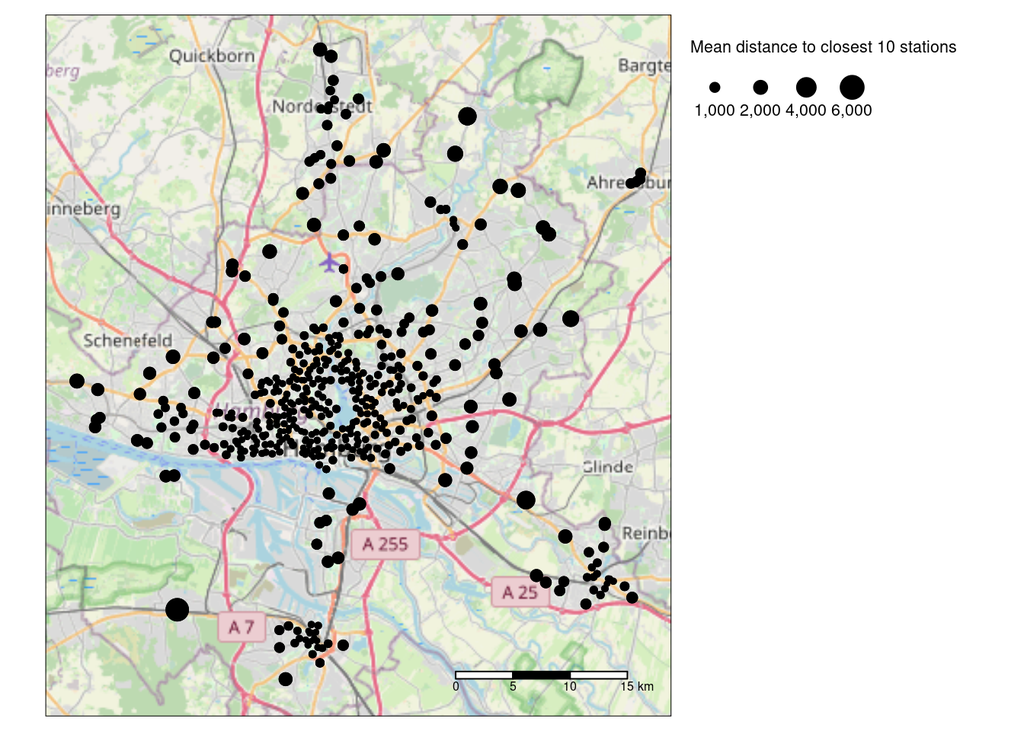

```r
tm_shape(osm_hh) + tm_rgb() + tm_shape(charging_stations) + tm_dots(size="meanDist10", legend.size.show = TRUE, title.size = "Mean distance to closest 10 stations" ) + tm_basemap(server= "OpenStreetMap.DE") + tm_layout(legend.outside=TRUE) + tm_scale_bar()
```

We see that distances are (not unexpectedly increaing from the city center).

A convenient and fast imlementations is *kNNdist* from the *dbscan* package:

```r
nn4Mat <- kNNdist(st_coordinates(charging_stations), k=4, all=TRUE)
head(nn4Mat)
```

```
##   1        2        3         4
## 1 0 425.1543 425.1543  425.1543
## 2 0 571.8326 571.8326 1319.5587
## 3 0 293.6338 293.6338  312.8868
## 4 0 139.8384 139.8384  196.5883
## 5 0   0.0000 382.7148  382.7148
## 6 0   0.0000 393.3024  393.3024
```

It returns the distance matrix for the *k* nearest neighbors.

## 2.3 Identify spatial clusters using dbscan

DBSCAN estimates the density around each data point by counting the number of points in a user-specified eps-neighborhood and applies a used-specified minPts thresholds to identify core, border and noise points. In a second step, core points are joined into a cluster if they are density-reachable (i.e., there is a chain of core points where one falls inside the eps-neighborhood of the next). Finally, border points are assigned to clusters. The algorithm only needs parameters eps and minPts.

```r
db_hh <- dbscan(st_coordinates(charging_stations), eps = 650, minPts = 7)
print(db_hh)
```

```
## DBSCAN clustering for 1061 objects.
## Parameters: eps = 650, minPts = 7
## The clustering contains 8 cluster(s) and 308 noise points.
##
##   0   1   2   3   4   5   6   7   8
## 308 639  42  27  10   9   9  10   7
##
## Available fields: cluster, eps, minPts
```

```r
charging_stations['dbCluster'] <- db_hh$cluster
nClust <- length(unique(db_hh$cluster))
```

```r
tmap_mode("view")
```

```
## tmap mode set to interactive viewing
```

```r
tm_shape(charging_stations) + tm_dots(col = "dbCluster", size=0.25, alpha=.5, palette="Accent", n=nClust) + tm_basemap(server= "OpenStreetMap.DE") + tm_scale_bar()
```

[interactive chart not shown]

# Exercise

Perform the same anlysis with the dataset chargingStations_berlin.shp. You can load the shapefile by simply passing the folder name and the name of the shapefile (including the .shp extension) to st_read. The data are in ETRS89 / UTM zone 33N (use a web search to get the EPSG number)